# spca_score_concordance_comparison

EYW

2026-08-17

```r
library(tidyverse)
library(patchwork)
library(viridisLite)
knitr::opts_chunk$set(echo = TRUE)
```

```r
source("../../functions/r_custom/plotting_fxns.R")
theme_set(theme_Publication())

plot_dir <- "../../analysis_outs/plots/qc_barcode_detailed"
dir.create(plot_dir, recursive = TRUE, showWarnings = FALSE)
```

# Goal

Are sPCA component scores associated with barcode UMI depth? `04_spca_waggr_countSubset_scoring.ipynb` re-ran the production `waggr` scoring on the top 30%, bottom 30%, and a score-agnostic random 30% of cells (by mean barcode score, within each `ligand_call_DSB7 x replicate` pseudobulk unit), plus the full population. All three subsets are matched in size by construction, and `random30` shows what a 30% subset looks like with no depth selection.

# Import

```r
scores <- read_csv("../../analysis_outs/qc_barcode_detailed/spca_waggr_countSubset_scores_long.csv.gz",
                   show_col_types = FALSE)
qc <- read_csv("../../analysis_outs/qc_barcode_detailed/spca_waggr_countSubset_qc.csv",
               show_col_types = FALSE)

comp_levels <- scores %>%
  distinct(component) %>%
  mutate(idx = as.integer(str_remove(component, "comp_"))) %>%
  arrange(idx) %>%
  pull(component)

scores <- scores %>% mutate(component = factor(component, levels = comp_levels))

scores %>% count(subset)
```

```
## # A tibble: 4 × 2
##   subset        n
##   <chr>     <int>
## 1 bottom30 102414
## 2 full     102414
## 3 random30 102414
## 4 top30    102414
```

```r
full_scores <- scores %>%
  filter(subset == "full") %>%
  select(unit_id, component, ligand_call_DSB7, replicate, score_full = score)

# per-component SD across pseudobulk units, used to standardise the score shifts below
comp_sd <- full_scores %>%
  group_by(component) %>%
  summarise(sd_full = sd(score_full), .groups = "drop")

unit_meta <- scores %>% distinct(unit_id, ligand_call_DSB7, replicate)

n_units <- n_distinct(full_scores$unit_id)
n_comps <- n_distinct(full_scores$component)
cat("pseudobulk units:", n_units, " components:", n_comps, "\n")
```

```
## pseudobulk units: 1313  components: 78
```

# Correlation of component scores

Here, we are looking at the absolute score values of sPCA-derived GEP in cells with top30, bottom30, or random30 barcode counts compared to the full data scores. We examine correlation and plot of component scores across treatment samples compared to the full-data scores.

```r
# overall correlation to full
scores %>%
  filter(subset != "full") %>%
  left_join(full_scores %>% select(unit_id, component, score_full),
            by = c("unit_id", "component")) %>%
  group_by(subset) %>%
  summarise(pearson = cor(score, score_full),
            spearman = cor(score, score_full, method = "spearman"),
            .groups = "drop")
```

```
## # A tibble: 3 × 3
##   subset   pearson spearman
##   <chr>      <dbl>    <dbl>
## 1 bottom30   0.994    0.979
## 2 random30   0.996    0.988
## 3 top30      0.995    0.982
```

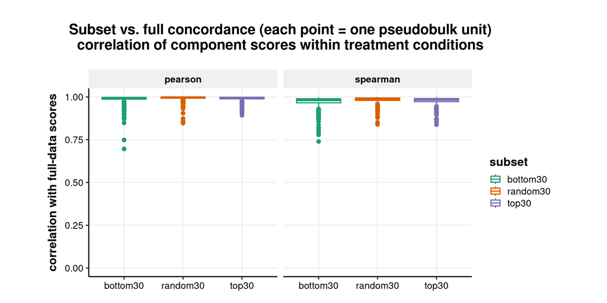

```r
p_conc <- scores %>%
  filter(subset != "full") %>%
  left_join(full_scores %>% select(unit_id, component, score_full),
            by = c("unit_id", "component")) %>%
  group_by(subset, unit_id) %>%
  summarise(pearson = cor(score, score_full),
            spearman = cor(score, score_full, method = "spearman"),
            .groups = "drop") %>%
  pivot_longer(c(pearson, spearman), names_to = "metric", values_to = "r") %>%
  ggplot(aes(x = subset, y = r, colour = subset)) +
  geom_boxplot() +
  ylim(0, 1) +
  facet_wrap(~metric) +
  theme(aspect.ratio = 1) +
  scale_color_brewer(palette = "Dark2") +
  labs(x = NULL, y = "correlation with full-data scores",
       title = "Subset vs. full concordance (each point = one pseudobulk unit)\ncorrelation of component scores within treatment conditions")

p_conc
```

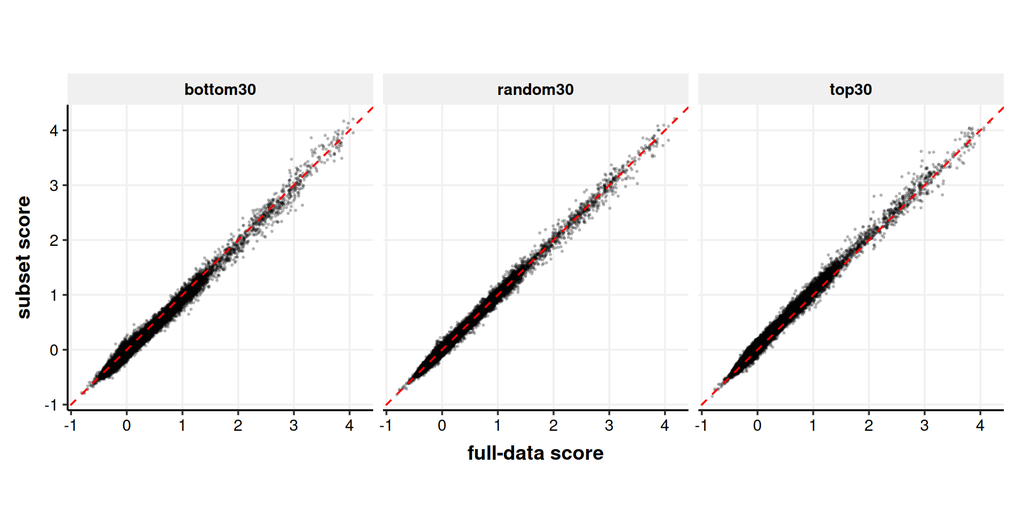

```r
ggsave(file.path(plot_dir, "spca_score_correlation_boxplots.pdf"))
p_scatter <- scores %>%
  filter(subset != "full") %>%
  left_join(full_scores %>% select(unit_id, component, score_full),
            by = c("unit_id", "component")) %>%
  ggplot(aes(x = score_full, y = score)) +
  geom_point(size = 0.3, alpha = 0.2) +
  geom_abline(slope = 1, intercept = 0, linetype = "dashed", colour = "red") +
  facet_wrap(~subset) +
  theme(aspect.ratio = 1) +
  labs(x = "full-data score", y = "subset score")

p_scatter
```

```r
ggsave(file.path(plot_dir, "spca_score_correlation_scatterplot.pdf"))
```